# Smart Streetlight Fault Detection

**Use Case Name:** Smart Streetlight Fault Detection Using Computer Vision  
**Authored by:** Syed Hamiz Hassan, Luke Kankanamge Don , Savith Mudunkotuwa, Josh Wong, Rahul Sheoran  
**Duration:** 90 mins  
**Level:** Intermediate  
**Pre-requisite Skills:** Python, Jupyter Notebook, Computer Vision, Deep Learning Basics, YOLO Object Detection, OpenCV, Data Analysis, Pandas, Matplotlib

# Scenario

As a local council maintenance team, we want an automated system that can detect streetlights and identify whether they are functioning correctly, dim, or completely off using nighttime street imagery, so that faulty streetlights can be identified efficiently without requiring manual inspection.

Traditional manual monitoring of streetlights can be time-consuming, expensive, and difficult to scale across large urban environments. This use case demonstrates how computer vision and deep learning can be used to automate streetlight monitoring through object detection and image analysis techniques.

# What this use case will teach you

At the end of this use case you will:

- Understand how object detection models such as YOLO can be used in real-world smart city applications
- Learn how to preprocess low-light images for improved detection performance
- Apply computer vision techniques using OpenCV
- Train and evaluate a YOLO-based streetlight detection model
- Perform image-based brightness analysis to classify streetlights as ON, DIM, or OFF
- Compare detection performance across multiple preprocessing techniques
- Generate visualisations and evaluation summaries using Python data analysis libraries
- Understand how AI solutions can support smart infrastructure maintenance

# Introduction

Streetlights are a critical component of urban infrastructure, which improve road safety, visibility, and public security during nighttime conditions. However, monitoring large numbers of streetlights manually is inefficient and costly. Faulty or dim streetlights may remain undetected for long periods especially on routes which are less frequently travelled on, leading to safety concerns and increased maintenance delays.

This use case presents an AI-driven smart streetlight fault detection system using computer vision and deep learning techniques. The solution uses the ExDark low-light image dataset alongside a custom-trained YOLO object detection model to identify streetlights in nighttime scenes. Additional RGB brightness analysis is then applied to classify detected streetlights into operational states such as ON, DIM, or OFF.

Multiple image enhancement approaches including brightness adjustment and CLAHE (Contrast Limited Adaptive Histogram Equalization) are evaluated to improve detection performance under challenging low-light conditions. The final system demonstrates how AI technologies can support smart city infrastructure by automating fault detection and improving maintenance efficiency.

```python
# Path for Dependency folder, kindly change it to your local path
from pathlib import Path

source_root = Path("/Users/hamizhassan16/Documents/MOP-Code/datascience/usecases/DEPENDENCIES/UC00229_Smart_Streetlight_Fault_Detection")
```

# Data Preperation

**Cell block changed from Code to markdown inorder to prevent accidental re run as output already run and saved in folder Predicted Streetlights folder in dependencies**

from ultralytics import YOLO model_path = source_root / "runs" / "detect" / "yolo11n.pt" model = YOLO(model_path) model.train( data=source_root / "Training Dataset" / "data.yaml", epochs=50, workers=0 )

### Helper functions for YOLO validation

Define small helper functions used to compare actual YOLO labels with predicted bounding boxes. The functions calculate the distance between bounding-box centres, compare box sizes, find the closest predicted box for each real label, and read YOLO label files from disk.

```python
from math import sqrt
def distance(x, y):
    return sqrt(x**2 + y**2)


def centre_distance(box1, box2):
    # box format: [x, y, w, h]
    return distance(box1[0] - box2[0], box1[1] - box2[1])


def size_difference(box1, box2):
    # box format: [x, y, w, h]
    width_diff = abs(box1[2] - box2[2])
    height_diff = abs(box1[3] - box2[3])
    return width_diff, height_diff


def closestcentre(true_box, predicted_boxes):
    min_distance = float("inf")
    closest_index = -1

    for i in range(len(predicted_boxes)):
        d = centre_distance(true_box, predicted_boxes[i])

        if d < min_distance:
            min_distance = d
            closest_index = i

    return closest_index, min_distance


def load_yolo_labels(label_path):
    boxes = []

    if not label_path.exists():
        return boxes

    with open(label_path, "r") as f:
        for line in f:
            values = line.strip().split()

            if len(values) == 5:
                class_id = int(values[0])
                x, y, w, h = map(float, values[1:])
                boxes.append([x, y, w, h, class_id])

    return boxes
```

### Validating YOLO detections against labelled validation images

Load the validation images and their YOLO label files, run the YOLO model on each image, and compare predicted streetlight boxes with the ground-truth labels. Record metrics such as actual object count, detected object count, matched objects, average centre distance, width/height differences, and class accuracy.

```python
from ultralytics import YOLO
import os
import shutil
from pathlib import Path
import numpy as np
import pandas as pd
val_image_dir = source_root / "Training Dataset" / "valid" / "images"
val_label_dir = source_root / "Training Dataset" / "valid" / "labels"
model_path = source_root / "runs" / "detect" / "yolo11n.pt"
model = YOLO(model_path)

val_rows = []

val_image_paths = (
    list(val_image_dir.glob("*.jpg")) +
    list(val_image_dir.glob("*.jpeg")) +
    list(val_image_dir.glob("*.png"))
)

for val_image_path in val_image_paths:
    val_label_path = val_label_dir / f"{val_image_path.stem}.txt"

    true_boxes = load_yolo_labels(val_label_path)

    results = model(str(val_image_path), verbose=False)

    pred_xywhn = results[0].boxes.xywhn.cpu().numpy()
    pred_classes = results[0].boxes.cls.cpu().numpy()

    pred_boxes = []
    for box, cls in zip(pred_xywhn, pred_classes):
        x, y, w, h = box
        pred_boxes.append([x, y, w, h, int(cls)])

    image_centre_distances = []
    image_width_differences = []
    image_height_differences = []
    class_matches = []

    unmatched_pred_indexes = set(range(len(pred_boxes)))

    for true_box in true_boxes:
        if len(pred_boxes) == 0:
            continue

        true_xywh = true_box[:4]

        available_preds = [pred_boxes[i][:4] for i in unmatched_pred_indexes]

        if len(available_preds) == 0:
            continue

        closest_local_idx, centre_dist = closestcentre(true_xywh, available_preds)

        actual_pred_idx = list(unmatched_pred_indexes)[closest_local_idx]
        matched_pred = pred_boxes[actual_pred_idx]

        unmatched_pred_indexes.remove(actual_pred_idx)

        width_diff, height_diff = size_difference(true_xywh, matched_pred[:4])

        image_centre_distances.append(centre_dist)
        image_width_differences.append(width_diff)
        image_height_differences.append(height_diff)
        class_matches.append(int(true_box[4] == matched_pred[4]))

    val_rows.append({
        "image": val_image_path.name,
        "actual_objects": len(true_boxes),
        "detected_objects": len(pred_boxes),
        "object_count_difference": abs(len(true_boxes) - len(pred_boxes)),
        "matched_objects": len(image_centre_distances),
        "avg_centre_distance": np.mean(image_centre_distances) if image_centre_distances else np.nan,
        "avg_width_difference": np.mean(image_width_differences) if image_width_differences else np.nan,
        "avg_height_difference": np.mean(image_height_differences) if image_height_differences else np.nan,
        "class_accuracy": np.mean(class_matches) if class_matches else np.nan
    })

val_val_metrics_df = pd.DataFrame(val_rows)

val_val_metrics_df
```

|  | image | actual_objects | detected_objects | object_count_difference | matched_objects | avg_centre_distance | avg_width_difference | avg_height_difference | class_accuracy |
| --- | --- | --- | --- | --- | --- | --- | --- | --- | --- |
| 0 | 04bf4bed-2015_02415.jpg | 1 | 2 | 1 | 1 | 0.652027 | 0.385711 | 0.104722 | 0.0 |
| 1 | 8ccb28d3-2015_02476.jpg | 0 | 4 | 4 | 0 | NaN | NaN | NaN | NaN |
| 2 | 3e92a002-2015_02463.jpg | 2 | 2 | 0 | 2 | 0.433388 | 0.250668 | 0.222132 | 0.0 |
| 3 | 4f687941-2015_02488.jpg | 0 | 3 | 3 | 0 | NaN | NaN | NaN | NaN |
| 4 | 0a5e5b9f-2015_02469.jpg | 1 | 8 | 7 | 1 | 0.024653 | 0.039665 | 0.017425 | 0.0 |
| 5 | 3e3a8da2-2015_02454.jpg | 0 | 2 | 2 | 0 | NaN | NaN | NaN | NaN |
| 6 | 5fdd5bd9-2015_02466.jpg | 3 | 2 | 1 | 2 | 0.224708 | 0.418726 | 0.165986 | 0.0 |
| 7 | 6f3ea208-2015_02425.jpg | 2 | 1 | 1 | 1 | 0.310101 | 0.153952 | 0.259666 | 0.0 |
| 8 | 3af3e8f9-2015_02452.jpg | 0 | 2 | 2 | 0 | NaN | NaN | NaN | NaN |
| 9 | 0caf98dc-2015_02458.jpg | 0 | 1 | 1 | 0 | NaN | NaN | NaN | NaN |
| 10 | 1d93710c-2015_02467.jpg | 0 | 3 | 3 | 0 | NaN | NaN | NaN | NaN |
| 11 | 3bb9bd32-2015_02479.jpg | 0 | 2 | 2 | 0 | NaN | NaN | NaN | NaN |
| 12 | 4d366f69-2015_02414.jpg | 11 | 10 | 1 | 10 | 0.288761 | 0.068572 | 0.135314 | 0.0 |
| 13 | 0c333709-2015_02417.jpg | 19 | 6 | 13 | 6 | 0.222790 | 0.090980 | 0.099240 | 0.0 |
| 14 | 2e7d3ba9-2015_02494.jpg | 0 | 1 | 1 | 0 | NaN | NaN | NaN | NaN |
| 15 | 1c342b80-2015_02432.jpg | 1 | 1 | 0 | 1 | 0.492760 | 0.130918 | 0.139797 | 0.0 |
| 16 | 4a5e7868-2015_02475.jpg | 0 | 4 | 4 | 0 | NaN | NaN | NaN | NaN |
| 17 | 0d21e294-2015_02492.jpg | 0 | 1 | 1 | 0 | NaN | NaN | NaN | NaN |
| 18 | 4f25c5ad-2015_02413.jpg | 1 | 3 | 2 | 1 | 0.177042 | 0.165464 | 0.021170 | 0.0 |
| 19 | 1b81a2e4-2015_02416.png | 1 | 4 | 3 | 1 | 0.221752 | 0.084722 | 0.405271 | 0.0 |

### Checking images where actual and detected counts match

Filter the validation results to show only images where the number of actual labelled objects equals the number of detected objects. This helps identify cases where the model predicted the correct number of streetlights, even if the box positions or classes still need checking.

```python
val_val_metrics_df[val_val_metrics_df["actual_objects"] == val_val_metrics_df["detected_objects"]]
```

|  | image | actual_objects | detected_objects | object_count_difference | matched_objects | avg_centre_distance | avg_width_difference | avg_height_difference | class_accuracy |
| --- | --- | --- | --- | --- | --- | --- | --- | --- | --- |
| 2 | 3e92a002-2015_02463.jpg | 2 | 2 | 0 | 2 | 0.433388 | 0.250668 | 0.222132 | 0.0 |
| 15 | 1c342b80-2015_02432.jpg | 1 | 1 | 0 | 1 | 0.492760 | 0.130918 | 0.139797 | 0.0 |

### Creating a validation summary table

Circulate overall validation statistics from the per-image results. The summary gives a quick view of model performance, including average actual objects, average detected objects, average detection difference, average matched boxes, and average bounding-box differences.

```python
summary_df = pd.DataFrame({
    "metric": [
        "Images evaluated",
        "Average actual objects",
        "Average detected objects",
        "Average object count difference",
        "Average matched objects",
        "Average centre distance",
        "Average width difference",
        "Average height difference",
        "Average class accuracy"
    ],
    "value": [
        len(val_val_metrics_df),
        val_val_metrics_df["actual_objects"].mean(),
        val_val_metrics_df["detected_objects"].mean(),
        val_val_metrics_df["object_count_difference"].mean(),
        val_val_metrics_df["matched_objects"].mean(),
        val_val_metrics_df["avg_centre_distance"].mean(),
        val_val_metrics_df["avg_width_difference"].mean(),
        val_val_metrics_df["avg_height_difference"].mean(),
        val_val_metrics_df["class_accuracy"].mean()
    ]
})

print(summary_df)
```

```
                            metric      value
0                 Images evaluated  20.000000
1           Average actual objects   2.100000
2         Average detected objects   3.100000
3  Average object count difference   2.600000
4          Average matched objects   1.300000
5          Average centre distance   0.304798
6         Average width difference   0.178938
7        Average height difference   0.157072
8           Average class accuracy   0.000000
```

**Changed Cell to Markdown to avoid large runtimes, as output already exists in Predicted Streetlights folder**

# Root folder containing image folders

image_root = source_root / "ExDark" source_folders = ["Bicycle", "Bus", "Car", "Motorbike"]

# Output root

output_root = source_root / "Predicted Streetlights"

conf_threshold = 0.25

# Supported image types

img_exts = {".jpg", ".jpeg", ".png", ".bmp", ".webp"}

# Create output folders

lights_img_dir = output_root / "Lights Detected" / "images" lights_lbl_dir = output_root / "Lights Detected" / "labels" nolights_img_dir = output_root / "No lights Detected" / "images"

lights_img_dir.mkdir(parents=True, exist_ok=True) lights_lbl_dir.mkdir(parents=True, exist_ok=True) nolights_img_dir.mkdir(parents=True, exist_ok=True)

total_images = 0 images_with_lights = 0 images_without_lights = 0

for folder_name in source_folders: folder_path = image_root / folder_name

```
if not folder_path.exists():
    print(f"Skipping missing folder: {folder_path}")
    continue

for image_path in folder_path.iterdir():
    if image_path.suffix.lower() not in img_exts:
        continue

    total_images += 1
    print(f"Processing: {image_path}")

    # Run inference
    results = model(str(image_path), conf=conf_threshold, verbose=False)
    result = results[0]

    # boxes.xywhn gives normalized x_center, y_center, width, height
    boxes_xywhn = result.boxes.xywhn
    boxes_cls = result.boxes.cls

    # Build YOLO-format label lines
    label_lines = []
    for cls_tensor, box_tensor in zip(boxes_cls, boxes_xywhn):
        cls_id = int(cls_tensor.item())
        x_center, y_center, width, height = box_tensor.tolist()

        line = f"{cls_id} {x_center} {y_center} {width} {height}"
        label_lines.append(line)

    # Create unique output image name to avoid collisions across folders
    output_stem = f"{folder_name}_{image_path.stem}"
    output_image_name = output_stem + image_path.suffix
    output_label_name = output_stem + ".txt"

    if len(label_lines) > 0:
        images_with_lights += 1

        # Copy image
        shutil.copy2(image_path, lights_img_dir / output_image_name)

        # Save label txt
        with open(lights_lbl_dir / output_label_name, "w", encoding="utf-8") as f:
            f.write("\n".join(label_lines))

    else:
        images_without_lights += 1

        # Copy image only
        shutil.copy2(image_path, nolights_img_dir / output_image_name)
```

print("\nDone.") print(f"Total images processed: {total_images}") print(f"Images with lights detected: {images_with_lights}") print(f"Images with no lights detected: {images_without_lights}")

**Output Summary:**

Done. Total images processed: 2320

Images with lights detected: 1023

Images with no lights detected: 1297

# Computer Vision Model

**Installing YOLO on system**

import subprocess import sys

def install(package): try: print(f"Installing {package}...") subprocess.check_call([sys.executable, "-m", "pip", "install", package]) except subprocess.CalledProcessError: print(f"Failed to install {package}")

def upgrade_pip(): print("Upgrading pip...") subprocess.check_call([sys.executable, "-m", "pip", "install", "--upgrade", "pip"])

def main(): print("Starting installation...")

```
# Step 1: Upgrade pip
upgrade_pip()

# Step 2: Install core packages
packages = [
    "ultralytics",
    "opencv-python",
    "numpy",
    "pillow",
    "matplotlib",
    "torch",
    "torchvision"
]

for pkg in packages:
    install(pkg)

print("\nInstallation complete!")

# Step 3: Verify installation
try:
    from ultralytics import YOLO
    print("\nUltralytics imported successfully!")

    model = YOLO("yolo11n.pt")
    print("YOLO11 model loaded successfully!")

except Exception as e:
    print("Error verifying installation:", e)
```

if **name** == "**main**": main()

Training Model - Commented this part results for it have been saved in train3/best.pt

**Turned to markdown cell to avoid running as model already trained, this code is for reference**

from ultralytics import YOLO

model = YOLO("yolo11n.pt")

model.train( data="street_light_dataset/data.yaml", epochs=20, imgsz=640, batch=8, fraction=0.25 )

Setup

### Importing libraries for computer vision experiments

This setup cell imports the main libraries used in the computer vision pipeline. YOLO is used for object detection, OpenCV is used for image preprocessing, NumPy and Pandas are used for numerical analysis, Matplotlib is used for visualisation, and shutil/os/csv are used for file handling.

```python
from ultralytics import YOLO
import os
import cv2
import shutil
import csv
import numpy as np
import matplotlib.pyplot as plt
import pandas as pd
```

Experiments performed

**Code in markdown cell to show process**

model = YOLO("runs/detect/train3/weights/best.pt") base_path = "ExDark" target_classes = ["Car", "Bicycle", "Bus", "Motorbike"] count = 0 max_images = 200 output_directory = "experiment_results" os.makedirs(output_directory, exist_ok=True)

### Image preprocessing functions

These functions improve low-light images before detection. `brighten_image` increases brightness and contrast, `apply_clahe` improves local contrast using CLAHE, and `brighten_then_clahe` combines both methods. These preprocessing steps are tested to see whether they improve streetlight detection in dark images.

```python
def brighten_image(image, alpha = 1.5, beta = 30):
    return cv2.convertScaleAbs(image, alpha = alpha, beta = beta)

def apply_clahe(image):
    lab = cv2.cvtColor(image, cv2.COLOR_BGR2LAB)
    l, a, b = cv2.split(lab)
    clahe = cv2.createCLAHE(clipLimit=3.0, tileGridSize=(8, 8))
    l_clahe = clahe.apply(l)
    merged = cv2.merge((l_clahe, a, b))
    return cv2.cvtColor(merged, cv2.COLOR_LAB2BGR)

def brighten_then_clahe(image):
    bright = brighten_image(image)
    return apply_clahe(bright)
```

Defining Experiments

experiments = { "experiment_1_original": lambda img: img, "experiment_2_brightened": lambda img: brighten_image(img), "experiment_3_clahe": lambda img: apply_clahe(img), "experiment_4_brightened_clahe": lambda img: brighten_then_clahe(img) }

Selecting Images

selected_images = [] count = 0 for cls in target_classes: class_dir = os.path.join(base_path, cls) if not os.path.isdir(class_dir): print(f"Directory {class_dir} does not exist. Skipping class {cls}.") continue for img_name in sorted(os.listdir(class_dir)): if img_name.lower().endswith((".jpg", ".jpeg", ".png")): img_path = os.path.join(class_dir, img_name) selected_images.append((cls, img_name, img_path)) count += 1 if count >= max_images: break if count >= max_images: break

print(f"Selected {len(selected_images)} images.")

Running Experiments

summary = {}

for exp_name, preprocess_func in experiments.items(): print(f"\nRunning {exp_name} ...")

```
exp_folder = os.path.join(output_directory, exp_name)
with_dir = os.path.join(exp_folder, "with_streetlight")
without_dir = os.path.join(exp_folder, "without_streetlight")

os.makedirs(with_dir, exist_ok=True)
os.makedirs(without_dir, exist_ok=True)

detected_count = 0
not_detected_count = 0

for cls, img_name, img_path in selected_images:
    img = cv2.imread(img_path)

    if img is None:
        print(f"Failed to read image {img_path}. Skipping.")
        continue

    processed_img = preprocess_func(img)
    results = model(processed_img, conf = 0.25, verbose = False)
    new_name = f"{cls}_{img_name}"

    if len(results[0].boxes)>0:
        detected_count += 1
        shutil.copy(img_path, os.path.join(with_dir, new_name))
    else:
        not_detected_count += 1
        shutil.copy(img_path, os.path.join(without_dir, new_name))

summary[exp_name] = {"With Streetlight": detected_count, "Without Streetlight": not_detected_count}
```

### Displaying experiment results without rerunning the full pipeline

This cell contains commented code that would print the experiment summary. It is kept as reference so the notebook shows how the results were produced, while avoiding rerunning expensive image-processing experiments unnecessarily.

```python
# Commented These to show execytion structure and output without re-running
# print("\nSummary of Results:")
# for exp_name, results in summary.items():
#    print(f"\n{exp_name}:")
#    print(f"  With Streetlight: {results['With Streetlight']} images")
#    print(f"  Without Streetlight: {results['Without Streetlight']} images")
```

```
Summary of Results:

experiment_1_original:
  With Streetlight: 5 images
  Without Streetlight: 195 images

experiment_2_brightened:
  With Streetlight: 6 images
  Without Streetlight: 194 images

experiment_3_clahe:
  With Streetlight: 4 images
  Without Streetlight: 196 images

experiment_4_brightened_clahe:
  With Streetlight: 5 images
  Without Streetlight: 195 images
```

Choosing experiment 4 to Perform Experiment 5 to double check images marked as without streetlight

source_experiment = "experiment_4_brightened_clahe" source_without_dir = os.path.join(output_directory, source_experiment, "without_streetlight")

experiment_5_name = "experiment_5_double_check_from_experiment_4" experiment_5_folder = os.path.join(output_directory, experiment_5_name)

exp5_with_dir = os.path.join(experiment_5_folder, "with_streetlight") exp5_without_dir = os.path.join(experiment_5_folder, "without_streetlight")

os.makedirs(exp5_with_dir, exist_ok=True) os.makedirs(exp5_without_dir, exist_ok=True)

def double_check_preprocess(image): return brighten_then_clahe(image)

exp5_detected = 0 exp5_not_detected = 0

for img_name in sorted(os.listdir(source_without_dir)): if img_name.lower().endswith((".jpg", ".jpeg", ".png")): img_path = os.path.join(source_without_dir, img_name)

```
    image = cv2.imread(img_path)
    if image is None:
        print(f"Failed to read {img_path}")
        continue

    processed_img = double_check_preprocess(image)

    # lower confidence for second-pass checking to make it more sensitive
    results = model(processed_img, conf=0.10, verbose=False)

    if len(results[0].boxes) > 0:
        exp5_detected += 1
        shutil.copy(img_path, os.path.join(exp5_with_dir, img_name))
    else:
        exp5_not_detected += 1
        shutil.copy(img_path, os.path.join(exp5_without_dir, img_name))
```

print("Experiment 5 complete.") print("With streetlight:", exp5_detected) print("Without streetlight:", exp5_not_detected)

**Output**

Experiment 5 complete. With streetlight: 15 Without streetlight: 180

### Updating the experiment summary after the double-check stage

This cell records the results from Experiment 5, where images previously classified as having no streetlights are checked again using a more sensitive detection setting. This helps recover possible missed detections from earlier experiments.

```python
# summary[experiment_5_name] = {
#     "With Streetlight": exp5_detected,
#     "Without Streetlight": exp5_not_detected
# }
# print(summary[experiment_5_name])

# print("\n===== UPDATED SUMMARY =====")
# for exp_name, result in summary.items():
#     print(f"\n{exp_name}:")
#     print(f"  With streetlight : {result['With Streetlight']}")
#     print(f"  Without streetlight : {result['Without Streetlight']}")
```

```
{'With Streetlight': 15, 'Without Streetlight': 180}

===== UPDATED SUMMARY =====

experiment_1_original:
  With streetlight : 5
  Without streetlight : 195

experiment_2_brightened:
  With streetlight : 6
  Without streetlight : 194

experiment_3_clahe:
  With streetlight : 4
  Without streetlight : 196

experiment_4_brightened_clahe:
  With streetlight : 5
  Without streetlight : 195

experiment_5_double_check_from_experiment_4:
  With streetlight : 15
  Without streetlight : 180
```

RGB output setup

exp5_with_dir = os.path.join( output_directory, "experiment_5_double_check_from_experiment_4", "with_streetlight" ) print("Experiment 5 folder:", exp5_with_dir)

### Classifying streetlight state using brightness

The function classifies each detected streetlight crop as `on`, `dim`, or `off`. Instead of using the average brightness of the whole crop, it uses the top 10% brightest pixels, which is more suitable for streetlights because the light source may occupy only a small part of the bounding box.

```python
#import numpy as np
#import cv2

def classify_streetlight_state(crop, off_threshold=80, dim_threshold=160):
    """
    Improved classification using brightest pixels instead of full crop average
    """

    if crop is None or crop.size == 0:
        return "unknown", 0

    gray = cv2.cvtColor(crop, cv2.COLOR_BGR2GRAY)

    # Flatten and take top 10% brightest pixels
    pixels = gray.flatten()
    pixels.sort()

    top_pixels = pixels[int(0.9 * len(pixels)):]  # top 10%
    mean_brightness = float(np.mean(top_pixels))

    # Classification
    if mean_brightness < off_threshold:
        state = "off"
    elif mean_brightness < dim_threshold:
        state = "dim"
    else:
        state = "on"

    return state, mean_brightness
```

Analyze detected images

experiment5_detailed_results = [] image_counts_list = []

total_streetlights = 0 total_on = 0 total_dim = 0 total_off = 0

for img_name in sorted(os.listdir(exp5_with_dir)): if img_name.lower().endswith((".jpg", ".jpeg", ".png")): img_path = os.path.join(exp5_with_dir, img_name)

```
    image = cv2.imread(img_path)
    if image is None:
        continue

    # SAME conditions as Experiment 5 to keep consistency
    processed_img = double_check_preprocess(image)
    results = model(processed_img, conf=0.10, verbose=False)

    boxes = results[0].boxes
    num_lights = len(boxes)

    on_count = 0
    dim_count = 0
    off_count = 0

    per_image_states = []

    for box in boxes:
        x1, y1, x2, y2 = box.xyxy[0].cpu().numpy()
        x1, y1, x2, y2 = map(int, [x1, y1, x2, y2])

        x1 = max(0, x1)
        y1 = max(0, y1)
        x2 = min(image.shape[1], x2)
        y2 = min(image.shape[0], y2)

        crop = image[y1:y2, x1:x2]

        state, brightness = classify_streetlight_state(crop)

        if state == "on":
            on_count += 1
            total_on += 1
        elif state == "dim":
            dim_count += 1
            total_dim += 1
        elif state == "off":
            off_count += 1
            total_off += 1

        per_image_states.append({
            "bbox": (x1, y1, x2, y2),
            "state": state,
            "brightness": brightness
        })

        total_streetlights += 1

    # store per-image result
    experiment5_detailed_results.append({
        "image_name": img_name,
        "streetlight_count": num_lights,
        "on": on_count,
        "dim": dim_count,
        "off": off_count,
        "details": per_image_states
    })

    image_counts_list.append((img_name, num_lights))
```

print("Analysis complete.") print("Total streetlights:", total_streetlights) print("On:", total_on) print("Dim:", total_dim) print("Off:", total_off)

**Output**

Analysis complete. Total streetlights: 21 On: 6 Dim: 6 Off: 9

Amount of lights on/off/dim

**Training another model, which would be trained on whole of dataset instead of just a fraction of it**

from ultralytics import YOLO

model_2 = YOLO("yolo11n.pt") model_2.train( data="street_light_dataset/data.yaml", epochs=50, imgsz=640, batch=16, fraction=1.0 )

Changed above cell to markdown as dont want to accidentaly trigger another training however above cell was run as code block to train the newer model with 100% of data

### Comparing the old model and improved model

Over here we compare detections from two trained YOLO models: the older model trained on a smaller fraction of the data and the improved model trained on the full dataset. Run both models on the same image set and compare how many images contain detected streetlights.

```python
import os
from ultralytics import YOLO

path_test = source_root / "runs" / "detect" / "train5" / "weights" / "best.pt"
model_test = YOLO(path_test) # model trained with 100% data
path_old = source_root / "runs" / "detect" / "train3" / "weights" / "best.pt"
model_old = YOLO(path_old) # model trained with 25% data
base_path = source_root / "ExDark"
target_classes = ["Car", "Bicycle", "Bus", "Motorbike"]

count = 0
max_images = 250  # limit
images_with_detections_test = 0
images_with_detections_old = 0

for cls in target_classes:
    folder = os.path.join(base_path, cls)

    for img in os.listdir(folder):
        if img.endswith((".jpg", ".png")):
            img_path = os.path.join(folder, img)

            results_test = model_test(img_path, verbose=False)
            if len(results_test[0].boxes) > 0:
                images_with_detections_test += 1

            results_old = model_old(img_path, verbose=False)
            if len(results_old[0].boxes) > 0:
                images_with_detections_old += 1

            count += 1
            if count >= max_images:
                break
    if count >= max_images:
        break

print("Processed images:", count)
print("Images with detections (Test):", images_with_detections_test)
print("Images with detections (Old):", images_with_detections_old)
```

```
Processed images: 250
Images with detections (Test): 12
Images with detections (Old): 5
```

Difference in performance can be clearly seen, Therefore model with larger dataset would be preferred over the older version. Ps newer model took 450.66 minutes to train. Now we will duplicate some of the experiments performed above with newer model for better accuracy

# Training Model WIth ExDark Dataset

# Using Groupmates Dataset

**Putting Code in markdown to avoid large runtimes as model already trained**

dataset_path = "Savith_data_exdark_train" data_yaml = os.path.join(dataset_path, "data.yaml") model = YOLO("yolo11n.pt") results = model.train( data=data_yaml, epochs=200, imgsz=640, batch=4, patience=50, name="streetlight_savith_best", project="runs/detect",

```
# augmentation for small dataset
degrees=10,
translate=0.1,
scale=0.5,
shear=2,
perspective=0.0005,
fliplr=0.5,
flipud=0.0,
mosaic=1.0,
mixup=0.1,

# optimization
optimizer="AdamW",
lr0=0.001,
weight_decay=0.0005,

# saving best model
save=True,
plots=True
```

)

Validating

best_model_path = source_root / "runs" / "detect" / "streetlight_savith_best" / "weights" / "best.pt" best_model = YOLO(best_model_path) best_model.predict( source=source_root / "Savith_data_exdark_train" / "valid" / "images", conf=0.25, save=True )

# Running on Model

model_path = source_root / "runs" / "detect" / "streetlight_savith_best" / "weights" / "best.pt" model = YOLO(model_path)

# Input ExDark folder

base_path = source_root / "ExDark"

# Output folder inside experiment_results

experiment_folder = os.path.join("experiment_results", "experiment_6_original_new_model")

with_folder = os.path.join(experiment_folder, "images_with_streetlights") without_folder = os.path.join(experiment_folder, "images_without_streetlights")

os.makedirs(with_folder, exist_ok=True) os.makedirs(without_folder, exist_ok=True)

# Target folders

target_classes = ["Car", "Bicycle", "Bus", "MotorBike"]

# Image formats

image_extensions = [".jpg", ".jpeg", ".png"]

total_images = 0 with_count = 0 without_count = 0

for class_name in target_classes: class_path = os.path.join(base_path, class_name)

```
if not os.path.exists(class_path):
    print(f"Folder not found: {class_path}")
    continue

for image_name in os.listdir(class_path):
    if not any(image_name.lower().endswith(ext) for ext in image_extensions):
        continue

    image_path = os.path.join(class_path, image_name)
    total_images += 1

    # Run detection
    results = model.predict(
        source=image_path,
        conf=0.25,
        verbose=False
    )

    boxes = results[0].boxes
    save_name = f"{class_name}_{image_name}"

    if boxes is not None and len(boxes) > 0:
        shutil.copy(image_path, os.path.join(with_folder, save_name))
        with_count += 1
    else:
        shutil.copy(image_path, os.path.join(without_folder, save_name))
        without_count += 1
```

print("\n=== Experiment 6 Completed ===") print(f"Total images: {total_images}") print(f"Images with streetlights: {with_count}") print(f"Images without streetlights: {without_count}") print(f"Saved in: {experiment_folder}")

**Output Experiment 6**

=== Experiment 6 Completed ===

Total images: 2320

Images with streetlights: 495

Images without streetlights: 1825

Saved in: experiment_results/experiment_6_original_new_model

# Model Finalized (Experiment 6 model)

# ------------------------------------

# Integrate output from Savith, Double check images and Running RGB Analysis

### Running final RGB analysis on Savith's detected images

This part uses the final trained YOLO model to validate the images prepared by Savith. For each detected streetlight, it crops the bounding box, applies brightness-based classification, and counts how many lights are `on`, `dim`, or `off`. The results are stored for later reporting and CSV export.

```python
savith_images_dir = source_root / "Predicted Streetlights" / "Lights Detected" / "images"

model_path = source_root / "runs" / "detect" / "streetlight_savith_best" / "weights" / "best.pt"
model = YOLO(model_path)
# Results storage
savith_detailed_results = []
savith_image_counts_list = []

total_streetlights = 0
total_on = 0
total_dim = 0
total_off = 0

# Loop through Savith's detected images
for img_path in sorted(savith_images_dir.iterdir()):
    if img_path.suffix.lower() not in [".jpg", ".jpeg", ".png"]:
        continue

    image = cv2.imread(str(img_path))
    if image is None:
        print(f"Could not read image: {img_path.name}")
        continue

    # Validate using trained YOLO model
    results = model.predict(
        source=str(img_path),
        conf=0.10,
        verbose=False
    )

    boxes = results[0].boxes
    num_lights = len(boxes)

    on_count = 0
    dim_count = 0
    off_count = 0

    per_image_states = []

    for box in boxes:
        x1, y1, x2, y2 = box.xyxy[0].cpu().numpy()
        x1, y1, x2, y2 = map(int, [x1, y1, x2, y2])

        # keep coordinates inside image
        x1 = max(0, x1)
        y1 = max(0, y1)
        x2 = min(image.shape[1], x2)
        y2 = min(image.shape[0], y2)

        crop = image[y1:y2, x1:x2]

        if crop.size == 0:
            continue

        # RGB / brightness classification
        state, brightness = classify_streetlight_state(crop)

        if state == "on":
            on_count += 1
            total_on += 1
        elif state == "dim":
            dim_count += 1
            total_dim += 1
        elif state == "off":
            off_count += 1
            total_off += 1

        per_image_states.append({
            "bbox": (x1, y1, x2, y2),
            "state": state,
            "brightness": brightness
        })

        total_streetlights += 1

    savith_detailed_results.append({
        "image_name": img_path.name,
        "streetlight_count": num_lights,
        "on": on_count,
        "dim": dim_count,
        "off": off_count,
        "details": per_image_states
    })

    savith_image_counts_list.append((img_path.name, num_lights))

print("Savith image validation + RGB analysis complete.")
print("Total streetlights:", total_streetlights)
print("On:", total_on)
print("Dim:", total_dim)
print("Off:", total_off)
```

```
Savith image validation + RGB analysis complete.
Total streetlights: 3349
On: 1744
Dim: 1192
Off: 413
```

### Saving overall RGB analysis results

This cell saves the total streetlight counts from the original image analysis into a text file. The file records the total number of detected streetlights and how many were classified as ON, DIM, and OFF.

```python
output_file = source_root / "rgb_original_results.txt"

# Write results to text file
with open(output_file, "w") as f:
    f.write("RGB Original Results\n")
    f.write("====================\n\n")
    f.write(f"Total streetlights detected: {total_streetlights}\n")
    f.write(f"ON streetlights: {total_on}\n")
    f.write(f"DIM streetlights: {total_dim}\n")
    f.write(f"OFF streetlights: {total_off}\n")

print(f"Results saved to {output_file}")
```

```
Results saved to rgb_original_results.txt
```

### Saving per-image RGB results to CSV

Here we write the RGB classification result for each image into a CSV file. Each row contains the image name, total detected streetlights, and the number of ON, DIM, and OFF lights. This file is useful for later analysis, graphing, and reporting.

```python
csv_file = source_root / "rgb_original_per_image.csv"

with open(csv_file, "w", newline="") as f:
    writer = csv.DictWriter(
        f,
        fieldnames=["image_name", "streetlight_count", "on", "dim", "off"]
    )

    writer.writeheader()

    for result in savith_detailed_results:
        writer.writerow({
            "image_name": result["image_name"],
            "streetlight_count": result["streetlight_count"],
            "on": result["on"],
            "dim": result["dim"],
            "off": result["off"]
        })

print(f"Per-image RGB results saved to: {csv_file}")
```

```
Per-image RGB results saved to: rgb_original_per_image.csv
```

### Running RGB analysis after brightening and CLAHE preprocessing

Repeating the streetlight detection and brightness classification after applying brightness enhancement and CLAHE. The goal is to compare whether preprocessing improves visibility and changes the ON, DIM, and OFF classification results.

```python
model_path = source_root / "runs" / "detect" / "streetlight_savith_best" / "weights" / "best.pt"
model = YOLO(model_path)

# Output CSV file
csv_file = source_root / "rgb_brightened_clahe_per_image.csv"

# Results storage
preprocessed_results = []
total_streetlights = 0
total_on = 0
total_dim = 0
total_off = 0


# Loop through Savith's detected images
for img_path in sorted(savith_images_dir.iterdir()):

    if img_path.suffix.lower() not in [".jpg", ".jpeg", ".png"]:
        continue

    image = cv2.imread(str(img_path))

    if image is None:
        print(f"Could not read image: {img_path.name}")
        continue

    # Apply preprocessing: brighten first, then CLAHE
    brightened_image = brighten_image(image)
    preprocessed_image = apply_clahe(brightened_image)

    # Validating using trained YOLO model on preprocessed image
    results = model.predict(
        source=preprocessed_image,
        conf=0.10,
        verbose=False
    )

    boxes = results[0].boxes
    num_lights = len(boxes)

    on_count = 0
    dim_count = 0
    off_count = 0

    per_image_states = []

    for box in boxes:

        x1, y1, x2, y2 = box.xyxy[0].cpu().numpy()
        x1, y1, x2, y2 = map(int, [x1, y1, x2, y2])

        # Keeping coordinates inside image
        x1 = max(0, x1)
        y1 = max(0, y1)
        x2 = min(preprocessed_image.shape[1], x2)
        y2 = min(preprocessed_image.shape[0], y2)

        crop = preprocessed_image[y1:y2, x1:x2]

        if crop.size == 0:
            continue

        # RGB / brightness classification on preprocessed crop
        state, brightness = classify_streetlight_state(crop)

        if state == "on":
            on_count += 1
            total_on += 1

        elif state == "dim":
            dim_count += 1
            total_dim += 1

        elif state == "off":
            off_count += 1
            total_off += 1

        per_image_states.append({
            "bbox": (x1, y1, x2, y2),
            "state": state,
            "brightness": brightness
        })

        total_streetlights += 1

    preprocessed_results.append({
        "image_name": img_path.name,
        "streetlight_count": num_lights,
        "on": on_count,
        "dim": dim_count,
        "off": off_count,
        "details": per_image_states
    })


# Save per-image results to CSV
with open(csv_file, "w", newline="") as f:

    writer = csv.DictWriter(
        f,
        fieldnames=["image_name", "streetlight_count", "on", "dim", "off"]
    )

    writer.writeheader()

    for result in preprocessed_results:
        writer.writerow({
            "image_name": result["image_name"],
            "streetlight_count": result["streetlight_count"],
            "on": result["on"],
            "dim": result["dim"],
            "off": result["off"]
        })

print("Brightened + CLAHE RGB analysis complete.")
print("Total streetlights:", total_streetlights)
print("On:", total_on)
print("Dim:", total_dim)
print("Off:", total_off)
print(f"Per-image results saved to: {csv_file}")
```

```
Brightened + CLAHE RGB analysis complete.
Total streetlights: 2419
On: 2084
Dim: 297
Off: 38
Per-image results saved to: rgb_brightened_clahe_per_image.csv
```

**Comparing results of rgb analysis on original images vs preprocessed images**

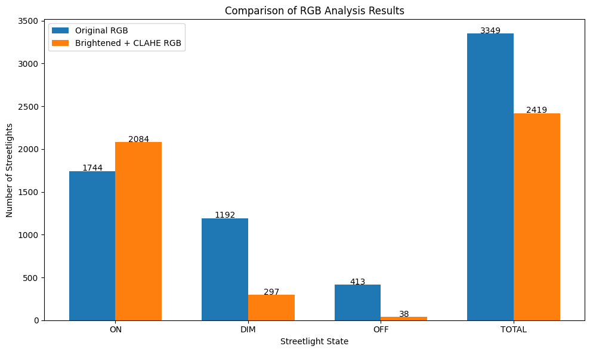

```python
# Load CSV files
original_df = pd.read_csv("rgb_original_per_image.csv")
preprocessed_df = pd.read_csv("rgb_brightened_clahe_per_image.csv")

# Calculating totals
original_on = original_df["on"].sum()
original_dim = original_df["dim"].sum()
original_off = original_df["off"].sum()
original_total = original_df["streetlight_count"].sum()

preprocessed_on = preprocessed_df["on"].sum()
preprocessed_dim = preprocessed_df["dim"].sum()
preprocessed_off = preprocessed_df["off"].sum()
preprocessed_total = preprocessed_df["streetlight_count"].sum()

# Categories
categories = ["ON", "DIM", "OFF", "TOTAL"]

# Values
original_values = [
    original_on,
    original_dim,
    original_off,
    original_total
]

preprocessed_values = [
    preprocessed_on,
    preprocessed_dim,
    preprocessed_off,
    preprocessed_total
]

# Bar positions
x = range(len(categories))
width = 0.35

# Create figure
plt.figure(figsize=(10, 6))

# Original bars
plt.bar(
    [i - width/2 for i in x],
    original_values,
    width=width,
    label="Original RGB"
)

# Preprocessed bars
plt.bar(
    [i + width/2 for i in x],
    preprocessed_values,
    width=width,
    label="Brightened + CLAHE RGB"
)

# Labels
plt.xticks(x, categories)
plt.ylabel("Number of Streetlights")
plt.xlabel("Streetlight State")
plt.title("Comparison of RGB Analysis Results")

for i, v in enumerate(original_values):
    plt.text(i - width/2, v + 2, str(v), ha='center')

for i, v in enumerate(preprocessed_values):
    plt.text(i + width/2, v + 2, str(v), ha='center')

plt.legend()
plt.tight_layout()
plt.show()
```

### ANALYSIS

The graph compares the RGB based streetlight state classification results between the original images and the images enhanced using brightening and CLAHE preprocessing. The preprocessing significantly change both the total number of deductive streetlights and the distribution of ON, DIM and OFF classifications. For the ON category , the preprocessed images produced 2084 street lights which were turned on compared to 1744 in the original images without any preprocessing. This shows an increase of 340 detections after preprocessing, suggesting that brightening and CLAHE improved illumination and contrast which made the active streetlights easier to identify. Dimly visible St. lights in the original data set were likely enhanced enough to be classified as fully turned on after preprocessing.

In contrast the dim category decreased sharply from 1192 in the original images down to 297. This large reduction indicates that many streetlights previously considered dim in the original images became clearer and brighter after preprocessing which caused them to shift into the on category. CLAHE improves local contrast, while brightness enhancement increases pixel intensity both of which strengthen the visibility of partially illuminated lights.

The OFF Category also reduced dramatically from 413 to only 38 detections. This suggests that preprocessing helps reveal hidden or poorly illuminated features that were difficult to observe in the original dark images. Many streetlights initially classified as turned off might have been reclassified after enhancement because the preprocessing amplified light regions and improved feature visibility which affected the model identifying the streetlights and reclassifying them.

However, the total number of detected streetlights decreased from 3349 in the original images to 2419 after preprocessing. This indicates that although preprocessing improved visibility and classification quality it may also have caused some reductions to be lost. Excessive brightening or contrast enhancement can alter object boundaries which introduce noise or change image characteristics enough to reduce Yolo detection sensitivity for certain streetlights.

Overall, the preprocessing pipeline appears highly effective for improving the recognition of illuminated streetlights, especially converting dim and of detections into on detections. The results demonstrate that brightening and clahe significantly improved the clarity and visibility of streetlights in low light environments. However, the reduction in total deduction suggests a trade off between enhanced visibility and object detection consistency. This means that preprocessing improves classification confidence but may reduce overall detection count in some cases.

# LLM Reporting

### Installing and importing LLM reporting libraries

```python
!pip install -q openai
!pip install -q -U google-genai
import os
import json
from openai import AsyncOpenAI
from google import genai
from google.genai import types
from dotenv import load_dotenv
import base64
from pathlib import Path
from PIL import Image
import matplotlib.pyplot as plt
```

**Defining functions for reporting**

# API KEY SETUP

```python
OPENAI_API_KEY = "Your OpenAI API Key Here"
```

### Creating the LLM prompt

This function builds the instruction prompt sent to the language model. It includes the streetlight count, ON/DIM/OFF counts, and detection details, then asks the model to return a concise professional maintenance report in JSON format.

```python
async def gen_prompt(data):

    prompt = f"""
        You are an AI-powered streetlight monitoring assistant.

        An uploaded streetlight image is provided together with ML detection results.
        Use both the image and the detection data to generate a professional, human-readable report.

        ML Detection Results:
        - Total Streetlights: {data["streetlight_count"]}
        - ON Lights: {data["on"]}
        - DIM Lights: {data["dim"]}
        - OFF Lights: {data["off"]}
        - Detection Details: {data["details"]}

        Instructions:
        - Analyze the uploaded image together with the ML output.
        - Describe the overall streetlight condition naturally.
        - Mention operational, dim, and faulty streetlights.
        - Highlight maintenance concerns if necessary.
        - Keep the response concise, professional, and humanized.
        - Do not mention Base64 data in the response.

        Return ONLY in this JSON format:

        {{
        "output": "your human-readable report here"
        }}
    """

    return prompt
```

### Sending the image and prompt to the LLM

This function sends both the text prompt and the uploaded streetlight image to the OpenAI model. The image is provided as a Base64 image URL, and the function returns the model response as parsed JSON.

```python
async def gpt(prompt, base64_image):

    gpt_client = AsyncOpenAI(api_key=OPENAI_API_KEY)

    chat_prompt = [
        {
            "role": "user",
            "content": [
                {"type": "text", "text": prompt},
                {"type": "image_url", "image_url": {"url": f"data:…"}}
            ]
        }
    ]

    completion = await gpt_client.chat.completions.create(
        model="gpt-4.1-mini",
        messages=chat_prompt,
        max_tokens=800,
        temperature=0,
        top_p=1,
        frequency_penalty=0,
        presence_penalty=0
    )

    response = completion.choices[0].message.content
    return json.loads(response)
```

### Combining prompt generation and LLM response

This wrapper function combines the full reporting workflow. It extracts the uploaded image, generates the prompt using the detection data, sends everything to the LLM, and returns the final report response.

```python
async def llm_reporting(data):

    base64_image = data["uploaded_image"]
    prompt = await gen_prompt(data)
    response = await gpt(prompt, base64_image)

    return response
```

Sample image for LLM Reporting

```python
img_path_long = Path("/Users/hamizhassan16/Documents/MOP-Code/datascience/usecases/DEPENDENCIES/UC00229_Smart_Streetlight_Fault_Detection")
img_path = img_path_long / "ExDark" / "Bicycle" / "2015_00002.png" # <- Change serial number of .png file to test with different images
with open(img_path, "rb") as img_file:
    encoded_image = base64.b64encode(
        img_file.read()
    ).decode("utf-8")
```

### Testing the LLM-generated report

Displaying the sample image and creating sample detection data to test the reporting pipeline. The generated output demonstrates how the system can convert CV results into a human-readable maintenance report.

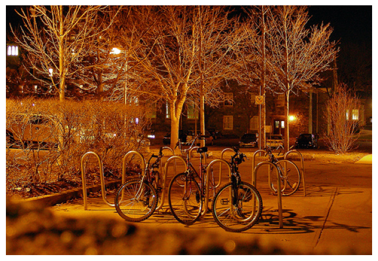

```
'The image shows a well-lit street area with five streetlights detected. All streetlights appear to be operational and fully illuminated, providing adequate lighting for the surroundings. There are no dim or non-functional lights observed, indicating that the streetlight system is currently in good …
```

```python
# Open image
image = Image.open(img_path)

# Display image
plt.figure(figsize=(8, 8))
plt.imshow(image)
plt.axis("off")
plt.show()

data = {
    "uploaded_image": encoded_image,
    "streetlight_count": len("boxes"),
    "on": "on_count",
    "dim": "dim_count",
    "off": "off_count",
    "details": "details"
}

response = await llm_reporting(data)
response["output"]
```

# UI code and walkthrough

**Using Streamlit**

# ======================================== FILE: backend_api/api.py

import sqlite3 import json import os from datetime import datetime from fastapi import FastAPI, UploadFile, File from typing import List from fastapi.staticfiles import StaticFiles from backend_api.models.cv_model import analyse_image from LLM.llm_reporting import llm_reporting import base64

# start API app

app = FastAPI()

# store image uploads

upload_directory = "uploads" os.makedirs(upload_directory, exist_ok = True)

app.mount("/uploads", StaticFiles(directory = "uploads"), name = "uploads")

# database path

db_path = "reports.db"

def init_db(): conn = sqlite3.connect(db_path) cursor = conn.cursor()

```
#create new database to store CV model analysis and LLM report
cursor.execute("""
    CREATE TABLE IF NOT EXISTS reports (
        id INTEGER PRIMARY KEY AUTOINCREMENT,
        report_id TEXT,
        timestamp TEXT,
        results TEXT
    )
""")

conn.commit()
conn.close()
```

init_db()

@app.get("/") def root(): return {"backend": "working"}

# DETECTION ENDPOINT FOR CV

@app.post("/detect") async def detect_lights(files: List[UploadFile] = File(...)): #create unique report folders for each individual report formatted y/m/d (year month day) and h/m/s (hours minutes seconds) report_id = datetime.now().strftime("%Y%m%d_%H%M%S") report_path = os.path.join(upload_directory, report_id) os.makedirs(report_path, exist_ok = True)

```
#for storing in the database and displaying results
saved_files = []
results = []

#process each individual file
for file in files:
    contents = await file.read()

    file_path = os.path.join(report_path, file.filename)

    #write uploaded image to the disk
    with open(file_path, "wb") as f:
        f.write(contents)

    #run CV model analysis
    analysis = analyse_image(file_path)

    #store result for a specific image, image = original file name and analysis = CV model analysis
    results.append({
        "image": file.filename,
        "analysis": analysis,
        "uploaded_img": base64.b64encode(contents).decode("utf-8")
    })

    saved_files.append(file.filename)

#return final response
return {
    "report_id": report_id,
    "results": results
}
```

# REPORT ENDPOINT FOR LLM

@app.post("/report") async def generate_report(data: dict): #get unique report ids report_id = data["report_id"]

```
final_results = []

#loop through each image
for item in data["results"]:

    analysis = item["analysis"]

    #send analysis to LLM for report generation
    llm_result = await llm_reporting({
        "analysis": analysis,
        "uploaded_img": item.get("uploaded_img")
    })

    #store results
    final_results.append({
        "image": item["image"],
        "analysis": analysis,
        "report": llm_result["output"]
    })

conn = sqlite3.connect(db_path)
cursor = conn.cursor()

#store values of analysis
cursor.execute("""
    INSERT INTO reports (report_id, timestamp, results)
    VALUES (?, ?, ?)
""", (
    report_id,
    datetime.now().isoformat(),
    json.dumps(final_results)
))

conn.commit()
conn.close()

#send response to the client
return {
    "report_id": report_id,
    "results": final_results
}
```

@app.get("/reports") def get_reports(): conn = sqlite3.connect(db_path) cursor = conn.cursor()

```
#fetch all reports with the most recent first
cursor.execute("""
    SELECT report_id, timestamp, results
    FROM reports
    ORDER BY id DESC
""")

rows = cursor.fetchall()
conn.close()

#convert rows to JSON format for API
reports = []
for row in rows:
    reports.append({
        "report_id": row[0],
        "timestamp": row[1],
        "results": json.loads(row[2])
    })

#return all reports
return {"reports": reports}
```

# ======================================== FILE: backend_api/models/cv_model.py

import os from ultralytics import YOLO import cv2 import numpy as np import base64

BASE_DIR = os.path.dirname(**file**)

MODEL_PATH = os.path.join(BASE_DIR, "best.pt")

# load YOLO model ONCE

model = YOLO(MODEL_PATH)

# -----------------------------

# -----------------------------

def brighten_image(image, alpha=1.5, beta=30): return cv2.convertScaleAbs(image, alpha=alpha, beta=beta)

def apply_clahe(image): lab = cv2.cvtColor(image, cv2.COLOR_BGR2LAB) l, a, b = cv2.split(lab)

```
clahe = cv2.createCLAHE(
    clipLimit=3.0,
    tileGridSize=(8, 8)
)

l_clahe = clahe.apply(l)

merged = cv2.merge((l_clahe, a, b))

return cv2.cvtColor(merged, cv2.COLOR_LAB2BGR)
```

def brighten_then_clahe(image): bright = brighten_image(image) return apply_clahe(bright)

# temporary substitute if missing

def double_check_preprocess(image): return brighten_then_clahe(image)

# -----------------------------

# -----------------------------

def classify_streetlight_state( crop, off_threshold=80, dim_threshold=160 ):

```
if crop is None or crop.size == 0:
    return "unknown", 0

gray = cv2.cvtColor(crop, cv2.COLOR_BGR2GRAY)

pixels = gray.flatten()
pixels = np.sort(pixels)

top_pixels = pixels[int(0.9 * len(pixels)):]

mean_brightness = float(np.mean(top_pixels))

if mean_brightness < off_threshold:
    state = "off"

elif mean_brightness < dim_threshold:
    state = "dim"

else:
    state = "on"

return state, mean_brightness
```

# -----------------------------

# -----------------------------

def analyse_image(image_path):

```
image = cv2.imread(image_path)

if image is None:
    return {
        "error": "Could not load image"
    }

processed_img = double_check_preprocess(image)

results = model(
    processed_img,
    conf=0.10,
    verbose=False
)

boxes = results[0].boxes

if boxes is None or len(boxes) == 0:
    return {
        "streetlight_count": 0,
        "on": 0,
        "dim": 0,
        "off": 0,
        "details": []
    }

on_count = 0
dim_count = 0
off_count = 0

details = []

for box in boxes:

    x1, y1, x2, y2 = box.xyxy[0].cpu().numpy()
    x1, y1, x2, y2 = map(int, [x1, y1, x2, y2])

    x1 = max(0, x1)
    y1 = max(0, y1)
    x2 = min(image.shape[1], x2)
    y2 = min(image.shape[0], y2)

    crop = image[y1:y2, x1:x2]

    state, brightness = classify_streetlight_state(crop)

    if state == "on":
        on_count += 1

    elif state == "dim":
        dim_count += 1

    elif state == "off":
        off_count += 1

    details.append({
        "bbox": [x1, y1, x2, y2],
        "state": state,
        "brightness": brightness
    })

with open(image_path, "rb") as img_file:
    encoded_image = base64.b64encode(
        img_file.read()
    ).decode("utf-8")

return {
    "uploaded_img": encoded_image,
    "streetlight_count": len(boxes),
    "on": on_count,
    "dim": dim_count,
    "off": off_count,
    "details": details
}
```

# ======================================== FILE: LLM/llm_reporting.py

import os import json

from openai import AsyncOpenAI

from dotenv import load_dotenv from pathlib import Path

load_dotenv(Path(**file**).resolve().parent.parent / ".env")

OPENAI_API_KEY = os.getenv("OPENAI_API_KEY")

async def gen_prompt(data):

```
analysis = data["analysis"]

prompt = f"""
You are an AI-powered streetlight monitoring assistant.

An uploaded streetlight image is provided together with ML detection results.

ML Detection Results:
- Total Streetlights: {analysis["streetlight_count"]}
- ON Lights: {analysis["on"]}
- DIM Lights: {analysis["dim"]}
- OFF Lights: {analysis["off"]}
- Detection Details: {analysis["details"]}

Instructions:
- Analyze the uploaded image together with the ML output.
- Describe the overall streetlight condition naturally.
- Mention operational, dim, and faulty streetlights.
- Highlight maintenance concerns if necessary.
- Keep the response concise and professional.
- Do not mention Base64 data.

Return ONLY valid JSON:

{{
    "output": "your report here"
}}
"""

return prompt
```

async def gpt(prompt, base64_image):

```
client = AsyncOpenAI(api_key=OPENAI_API_KEY)

completion = await client.chat.completions.create(
    model="gpt-4.1-mini",

    messages=[
        {
            "role": "user",
            "content": [
                {
                    "type": "text",
                    "text": prompt
                },
                {
                    "type": "image_url",
                    "image_url": {
                        "url": f"data:…"
                    }
                }
            ]
        }
    ],

    max_tokens=800,
    temperature=0
)

response = completion.choices[0].message.content

return json.loads(response)
```

async def llm_reporting(data):

```
base64_image = data["uploaded_img"]

prompt = await gen_prompt(data)

response = await gpt(prompt, base64_image)

return response
```

# ======================================== FILE: User_Interface/ui.py

import streamlit as st import requests import base64

# PAGECONFIG

st.set_page_config( page_title = "Smart Streetlight Fault Detection", layout = "centered", initial_sidebar_state = "expanded" )

# send images to FastAPI

def backend_detect(files): try: url = "http://localhost:8000/detect" response = requests.post(url, files = files) return response.json() except: return {"error": "Backend unavailable"}

# send detection results to FastAPI

def backend_report(detection_data): try: url = "http://localhost:8000/report" response = requests.post(url, json = detection_data) return response.json() except: return {"error": "Backend unavailable"}

def backend_get_reports(): try: response = requests.get("http://localhost:8000/reports") return response.json() except: return {"reports": []}

st.sidebar.title("Navigation") page = st.sidebar.radio("Go to", ["Homepage", "Detection", "Reports", "Report History", "About"])

# HOMEPAGE

if page == "Homepage": st.title(":blue[Smart Streetlight Fault Detection] :bulb:", text_alignment = "center")

```
st.markdown("""
            This project utilises a vision-based system to analyse provided nighttime images and detects faulty streetlights, specifically:
            - Streetlights that are either
                - **not functioning**
                - **flickering**
                - **producing a weak illumination**

            Following this, a maintenence alert will be generated.

            Please proceed to the detection page to get started. """)
```

# DETECTIONPAGE

elif page == "Detection": st.title("Streetlight Analysis")

```
#columns
col1, col2 = st.columns([1, 2])

with col1:
#file uploader
    uploaded_files = st.file_uploader("Upload image(s)", accept_multiple_files = True, type = ["jpg", "png"])

with col2:
#loop through uploaded files, display preview, and add a button
    if uploaded_files:
        st.header("Preview uploaded images")
        for file in uploaded_files:
            st.image(file, width="stretch")
            st.markdown("---")

        #button for analysis
        if st.button("Analyse image(s)", type = "primary"):
            with st.spinner("Analysing images..."):
                #prep files
                file_data = [
                    ("files", (file.name, file.getvalue(), file.type))
                    for file in uploaded_files
                ]

                #send to backend
                result = backend_detect(file_data)
                if isinstance(result, dict) and "results" in result:
                    st.session_state["analysis_result"] = result
                    st.success("Analysis complete!")
                else:
                    st.error("Backend returned invalid response")
                    st.json(result)
    else:
        st.info("No uploaded images.")

#DIVIDE PAGE
st.markdown("---")

#analysis results section
st.header("Analysis Results")
if "analysis_result" in st.session_state:
    result_data = st.session_state["analysis_result"]

    #check data is in correct format, if yes then loop through each analysed image result
    if isinstance(result_data, dict) and "results" in result_data:
        for result in result_data["results"]:

            analysis = result["analysis"]
            st.subheader(result["image"])

            #display uploaded image
            if "uploaded_img" in analysis:
                image_bytes = base64.b64decode(
                    analysis["uploaded_img"]
                )
                st.image(image_bytes)

            #summary for each image
            st.write(f"Streetlights: {analysis['streetlight_count']}")
            st.write(f"On: {analysis['on']}")
            st.write(f"Dim: {analysis['dim']}")
            st.write(f"Off: {analysis['off']}")

            st.json(analysis["details"])

            st.markdown("---")
else:
    st.info("No analysis results")
```

# REPORTSPAGE

elif page == "Reports": st.title("Maintenance Report")

```
if st.button("Generate report", type = "primary"):
    if "analysis_result" not in st.session_state:
        st.warning("No results available. Please run detection analysis first")
    else:
        with st.spinner("Generating report..."):
            #retrieve previously stored CV detection results
            detection_data = st.session_state['analysis_result']

            #send to backend
            report = backend_report(detection_data)

        if isinstance(report, dict) and "results" in report:
            st.success("Report generated!")

            #display LLM reports for each image
            for item in report["results"]:
                st.subheader(item["image"])
                st.write(item["report"])
                st.markdown("---")
        else:
            st.error("Report failed or invalid response from backend")
            st.json(report)
```

# REPORTHISTORY

elif page == "Report History": st.title("Report History")

```
#fetch all stored reports from database
data = backend_get_reports()
reports = data.get("reports", [])

if not reports:
    st.warning("No reports found. ")
else:
    #loop through all reports
    for report in reports:
        st.subheader(f"Report: {report['report_id']}")

        #for each image, display the URL, raw CV analysis, and LLM generated report
        for item in report["results"]:
            image_name = item["image"]

            image_url = f"http://localhost:8000/uploads/{report['report_id']}/{image_name}"

            st.image(image_url, width = "stretch")

            st.json(item["analysis"])

            if "report" in item:
                st.success(item["report"])
            else:
                st.warning("No LLM report available")
```

# ABOUTPAGE

elif page == "About": st.title(":blue[About Us]", text_alignment = "center")

```
st.markdown("""
        Our project team is composed of the following members:

        **Syed Hamiz Hassan**
        - Computer Vision Modelling


        **Savith Mundukotuwa**
        - Data Preparation


        **Josh Wong**
        - User Interface and System Integration


        **Luke Kankannamge Don**
        - LLM Reporting System


        **Rahul Sheoran**
        - Model Analysis

        """)
```

# ======================================== FILE: .env.example

OPENAI_API_KEY=your_api_key_here

# Model Analysis

### Final model optimisation analysis

This section validates the final YOLO model and tests different confidence thresholds. The purpose is to understand how confidence settings affect detection performance and to choose a suitable threshold for the final streetlight detection pipeline.

```python
from ultralytics import YOLO
import pandas as pd
import matplotlib.pyplot as plt

# ==========================================
# YOLO MODEL OPTIMISATION ANALYSIS
# ==========================================

# Load trained YOLO model
model_path = source_root / "runs" / "detect" / "streetlight_savith_best" / "weights" / "best.pt"
model = YOLO(model_path)

print("YOLO model loaded successfully.")

# ==========================================
# MODEL VALIDATION
# ==========================================

results = model.val(
    imgsz=640,
    batch=8,
    conf=0.25,
    iou=0.5,
    verbose=False
)

print("\nValidation completed.")

# ==========================================
# OPTIMISATION ANALYSIS
# ==========================================

confidence_values = [0.25, 0.35, 0.45, 0.55]

analysis_results = []

for conf_value in confidence_values:

    print(f"\nRunning analysis with confidence threshold: {conf_value}")

    result = model.val(
        imgsz=640,
        batch=8,
        conf=conf_value,
        iou=0.5,
        verbose=False
    )

    analysis_results.append({
        "Confidence": conf_value,
        "mAP50": float(result.box.map50),
        "mAP50-95": float(result.box.map),
        "Precision": float(result.box.mp),
        "Recall": float(result.box.mr)
    })

# ==========================================
# SAVE RESULTS
# ==========================================

df = pd.DataFrame(analysis_results)

print("\nOptimisation Results:")
print(df)

df.to_csv(source_root / "yolo_analysis_results.csv", index=False)

# ==========================================
# VISUALISATION
# ==========================================

plt.figure(figsize=(8, 5))

plt.plot(df["Confidence"], df["mAP50"], marker="o", label="mAP50")
plt.plot(df["Confidence"], df["Precision"], marker="o", label="Precision")
plt.plot(df["Confidence"], df["Recall"], marker="o", label="Recall")

plt.xlabel("Confidence Threshold")
plt.ylabel("Performance Score")
plt.title("YOLO Model Optimisation Analysis")

plt.legend()
plt.grid(True)

plt.tight_layout()

plt.savefig(source_root / "yolo_analysis_graph.png")

plt.show()

print("\nAnalysis completed successfully.")
print("Results saved as yolo_analysis_results.csv")
print("Graph saved as yolo_analysis_graph.png")
```

[output not shown]

[output not shown]

```
Analysis completed successfully.
Results saved as yolo_analysis_results.csv
Graph saved as yolo_analysis_graph.png
```